# R Notebook

```r
model_clas_xgbtree
```

```
eXtreme Gradient Boosting

3717 samples
  18 predictor

No pre-processing
Resampling: Cross-Validated (10 fold)
Summary of sample sizes: 3345, 3346, 3345, 3346, 3347, 3345, ...
Resampling results across tuning parameters:

  eta  max_depth  colsample_bytree  subsample  nrounds  RMSE        Rsquared   MAE
  0.3  1          0.6               0.50        50      0.10615828  0.4227597  0.08221790
  0.3  1          0.6               0.50       100      0.10302287  0.4461299  0.07934512
  0.3  1          0.6               0.50       150      0.10220966  0.4539257  0.07884518
  0.3  1          0.6               0.75        50      0.10680569  0.4199918  0.08304121
  0.3  1          0.6               0.75       100      0.10300721  0.4476827  0.07968281
  0.3  1          0.6               0.75       150      0.10179404  0.4589059  0.07874553
  0.3  1          0.6               1.00        50      0.10712915  0.4218410  0.08336429
  0.3  1          0.6               1.00       100      0.10337697  0.4472271  0.08010526
  0.3  1          0.6               1.00       150      0.10223590  0.4563268  0.07910629
  0.3  1          0.8               0.50        50      0.10608741  0.4221448  0.08214353
  0.3  1          0.8               0.50       100      0.10295577  0.4470899  0.07942441
  0.3  1          0.8               0.50       150      0.10184708  0.4577058  0.07846750
  0.3  1          0.8               0.75        50      0.10652661  0.4237035  0.08301394
  0.3  1          0.8               0.75       100      0.10296882  0.4483419  0.07966424
  0.3  1          0.8               0.75       150      0.10192504  0.4571984  0.07870365
  0.3  1          0.8               1.00        50      0.10691297  0.4256002  0.08320885
  0.3  1          0.8               1.00       100      0.10333172  0.4476876  0.07988840
  0.3  1          0.8               1.00       150      0.10216760  0.4569518  0.07887852
  0.3  2          0.6               0.50        50      0.10077622  0.4697228  0.07773634
  0.3  2          0.6               0.50       100      0.09883146  0.4901650  0.07567603
  0.3  2          0.6               0.50       150      0.09804406  0.4995478  0.07475524
  0.3  2          0.6               0.75        50      0.10025260  0.4763826  0.07725998
  0.3  2          0.6               0.75       100      0.09748770  0.5034727  0.07467404
  0.3  2          0.6               0.75       150      0.09626181  0.5159901  0.07368631
  0.3  2          0.6               1.00        50      0.10065663  0.4726613  0.07777123
  0.3  2          0.6               1.00       100      0.09817573  0.4962202  0.07535775
  0.3  2          0.6               1.00       150      0.09680131  0.5099545  0.07397708
  0.3  2          0.8               0.50        50      0.10063413  0.4709184  0.07741525
  0.3  2          0.8               0.50       100      0.09866003  0.4912938  0.07579846
```

[output cut: 71 more lines]

```
  0.4  3          0.8               0.50       100      0.09875365  0.4977583  0.07427005
  0.4  3          0.8               0.50       150      0.09859013  0.5033893  0.07311131
  0.4  3          0.8               0.75        50      0.09743058  0.5056018  0.07432487
  0.4  3          0.8               0.75       100      0.09607414  0.5216430  0.07228037
  0.4  3          0.8               0.75       150      0.09529973  0.5311202  0.07057222
  0.4  3          0.8               1.00        50      0.09671192  0.5111192  0.07350334
  0.4  3          0.8               1.00       100      0.09449860  0.5339198  0.07056355
  0.4  3          0.8               1.00       150      0.09315264  0.5476891  0.06863912

Tuning parameter 'gamma' was held constant at a value of 0
Tuning parameter
 'min_child_weight' was held constant at a value of 1
RMSE was used to select the optimal model using the smallest value.
The final values used for the model were nrounds = 150, max_depth = 3, eta = 0.3, gamma =
 0, colsample_bytree = 0.8, min_child_weight = 1 and subsample = 1.
```

A continuación, se muestra en una gráfica en la que el eje x serán los valores predecidos por el modelo y el eje y los valores verdaderos, cómo de bien predice cada modelo. La idea es que cada punto esté lo más cerca posible de la recta.

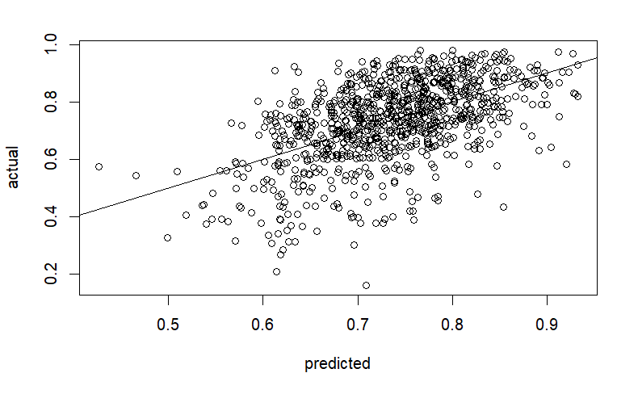

```r
predicted_glm <- predict.train(model_clas_glm,newdata = testData)
plot(predicted_glm, testData$danceability, xlab="predicted", ylab="actual")
abline(a=0,b=1)
```

```r
summary(predicted_glm)
```

```
   Min. 1st Qu.  Median    Mean 3rd Qu.    Max.
 0.4260  0.6841  0.7379  0.7352  0.7881  0.9330
```

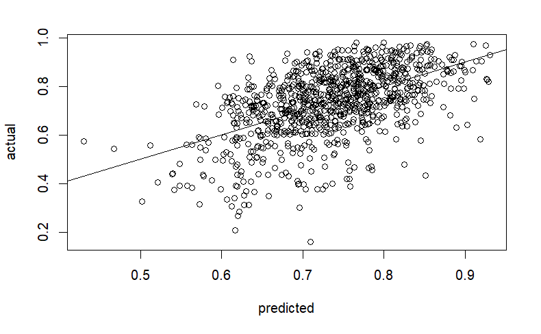

```r
predicted_glmnet <- predict.train(model_clas_glmnet,newdata = testData)
plot(predicted_glmnet, testData$danceability, xlab="predicted", ylab="actual")
abline(a=0,b=1)
```

```r
summary(predicted_glmnet)
```

```
   Min. 1st Qu.  Median    Mean 3rd Qu.    Max.
 0.4300  0.6843  0.7372  0.7351  0.7869  0.9311
```

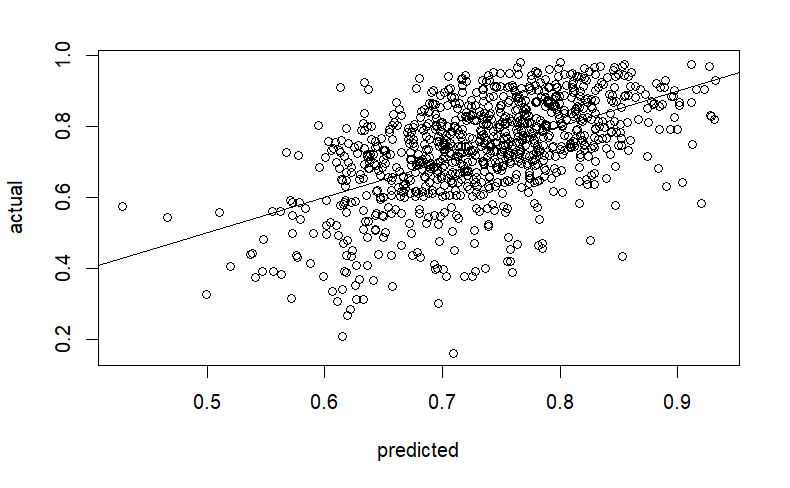

```r
predicted_glmnet_tunning <- predict.train(model_clas_glmnet_tunning,newdata = testData)
plot(predicted_glmnet_tunning, testData$danceability, xlab="predicted", ylab="actual")
abline(a=0,b=1)
```

```r
summary(predicted_glmnet_tunning)
```

```
   Min. 1st Qu.  Median    Mean 3rd Qu.    Max.
 0.4278  0.6842  0.7375  0.7352  0.7877  0.9322
```

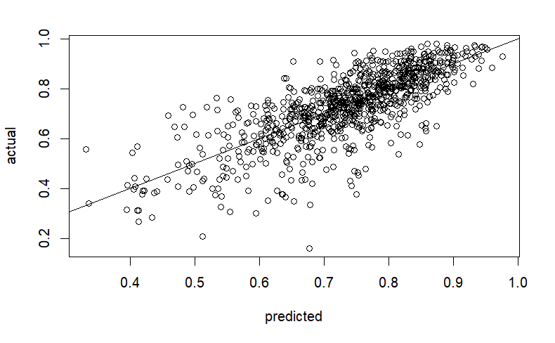

```r
predicted_xgbtree <- predict.train(model_clas_xgbtree,newdata = testData)
plot(predicted_xgbtree, testData$danceability, xlab="predicted", ylab="actual")
abline(a=0,b=1)
```

```r
summary(predicted_xgbtree)
```

```
   Min. 1st Qu.  Median    Mean 3rd Qu.    Max.
 0.3315  0.6747  0.7488  0.7361  0.8169  0.9763
```

Finalmente, se comparan los 4 modelos que hemos obtenido, viendo las métricas que se han obtenido en cada uno tanto viendo los valores con la función summary como visualmente usando las funciones dotplot y bwplot

```r
options(warn=oldw)
model_list <- list(
   glm = model_clas_glm,
   glmnet = model_clas_glmnet,
   glmnet_tunning = model_clas_glmnet_tunning,
   xgbTree = model_clas_xgbtree
 )

 # Pass model_list to resamples(): resamples
 resamples <- resamples(model_list)
```

```r
summary(resamples)
```

```
Call:
summary.resamples(object = resamples)

Models: glm, glmnet, glmnet_tunning, xgbTree
Number of resamples: 10

MAE
                     Min.    1st Qu.     Median       Mean    3rd Qu.       Max. NA's
glm            0.08696594 0.09052841 0.09161741 0.09122244 0.09197569 0.09595536    0
glmnet         0.08736079 0.09026715 0.09110281 0.09131466 0.09133598 0.09628816    0
glmnet_tunning 0.08722474 0.08890100 0.09158019 0.09127126 0.09259185 0.09686807    0
xgbTree        0.06533820 0.06767188 0.06879445 0.06903226 0.06963122 0.07519372    0

RMSE
                     Min.    1st Qu.     Median       Mean    3rd Qu.      Max. NA's
glm            0.11156853 0.11595192 0.11681365 0.11668299 0.11846795 0.1218709    0
glmnet         0.11006252 0.11494064 0.11720802 0.11681908 0.11851483 0.1224021    0
glmnet_tunning 0.10936080 0.11406604 0.11587547 0.11665973 0.11972494 0.1228294    0
xgbTree        0.08684187 0.09157313 0.09186986 0.09248653 0.09375949 0.1021524    0

Rsquared
                    Min.   1st Qu.    Median      Mean   3rd Qu.      Max. NA's
glm            0.2479482 0.2666231 0.2823212 0.2904049 0.3190370 0.3419991    0
glmnet         0.2375357 0.2577922 0.2896991 0.2883237 0.3091173 0.3625717    0
glmnet_tunning 0.2149798 0.2616275 0.3040429 0.2895385 0.3254823 0.3348828    0
xgbTree        0.4775328 0.5257955 0.5514692 0.5523922 0.5737810 0.6285829    0
```

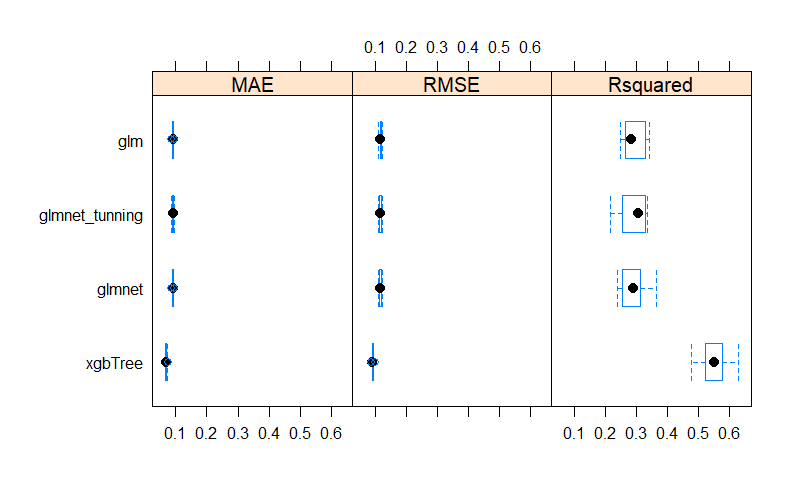

```r
bwplot(resamples)
```

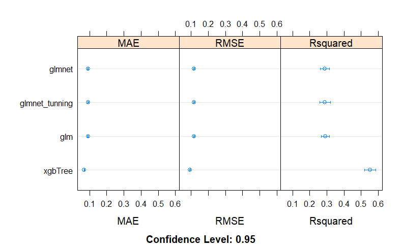

```r
dotplot(resamples)
```